# Shifts in Financial Aid Applications and Financing for Higher Education Programs Across New York

Data Science 1 Final Project: Long-Form Exploratory Data Analysis

Author

Elizabeth Casolo

Published

December 4, 2022

## Introduction

In a few weeks, MSNBC will release its new documentary *Loan Wolves* about the student loan crisis in the United States. As discussions about financial aid are on the rise, I wanted to address various financial aid offerings for students, specifically in the state of New York. Growing up in the New York metropolitan area, I had several family members living and going to school in New York state. New York has its own financial aid offering (known as the [Tuition Assistance Program](https://www.hesc.ny.gov/pay-for-college/apply-for-financial-aid/nys-tap.html), or TAP) that acts as a grant, meaning students do not have to pay it back.

Beyond New York state providing grants to students, post-secondary students can also fill out the Free Application for Federal Student Aid (FAFSA). This application allows students to potentially access financial aid plans overseen by the U.S. Department of Education. According to [StudentAid.Gov](https://studentaid.gov/understand-aid/types), some of these financial aid types include scholarships, loans, work-study jobs, and aid for families in special circumstances.

Uncovering trends — relating to school type, geography, and other factors — about the distribution of financial aid plans across a state as large as New York provides greater insight into the financial aid system as a whole.

I explored three data sets: [FAFSA application data from Q7 of the 2019-2020 application cycle](https://studentaid.gov/data-center/student/application-volume/fafsa-school-state), [TAP data by school beginning in 2000](https://catalog.data.gov/dataset/tuition-assistance-program-tap-recipients-dollars-by-college-sector-group-and-level-of-stu), and [the Federal School Code List for participating schools (2022-2023)](https://fsapartners.ed.gov/knowledge-center/library/federal-school-code-lists/2022-08-18/2022-23-federal-school-code-list-participating-schools-august-2022). I chose the first two to learn more about TAP and FAFSA plans across schools in New York. For the FAFSA data, I chose the most up-to-date data available that would coincide with the most recent year for the TAP data (Q7 of the 2019-2020 cycle). I used the third data set to merge the first two and add some geographical information about each school. By collecting data from the U.S. government, I hope to form reliable conclusions about the status of financial aid across schools in New York.

My goals for this project include assessing financial aid application/funding changes between higher education programs in different cities/towns/boroughs throughout New York. I also want to review shifts in TAP funding from 2000 through 2020.

This project will provide a comprehensive overview of how different variables influence financial aid applications and funding changes for higher education institutions across New York.

## Data Processing

In order to clean these data sets, I needed to convert variable names to snake case and acknowledge different variable types. The FAFSA and federal school code sets started out with only character variables, while the TAP data had a mix of numeric and character variables. I changed these variable types to more appropriate ones, once learning New York schools had exclusively numeric federal school codes and figuring some variables would work better as factors, numbers, or characters.

Before proceeding, I also cleaned up the FAFSA application data, considering how the formatting was not suitable for conducting a data analysis.

To merge these sets, I needed to use string coding, specifically `str_pad` and `str_detect`, to manipulate the federal school codes to have similar formats. Some codes had `0`s acting as padding, whereas otherwise were centered differently or had no padding. Once these concerns were addressed, I was able to continue with the merge.

I decided to merge my data sets based on institution names (to have a data set containing TAP data and schools’ geographical information) and federal school code (to combine all three data sets for the 2020 year). Based on my research objectives, I created two data sets: one covering TAP funding and FAFSA applications (with geographical information) in 2020 and another addressing TAP funding (with geographical information) from 2000 through 2020.

Not all of the originally listed schools had matches across data sets. Some schools were excluded due to the lack of a matching federal school code (indicating that the specific school program may have been listed as one for just graduate students, like in the case of some of Bard College’s graduate programs). I’ll consider these differences (i.e. by filtering out graduate institutions when appropriate) while proceeding with my data analysis. For the 2020-specific data, I only looked at undergraduate programs.

Although some of the rows containing `NA` values were removed during the data cleaning process, I also removed some geographical columns that had exclusively `NA` values. Not all of the rows with `NA` values had a match between the data sets. However, even after cleaning and merging these data sets, some `NA` values remain. In terms of persistent missinginess, some quarter 7 FAFSA application information is missing from the 2020-specific set. Fourteen programs, specifically, did not have records for any of the full-year or quarter 7 FAFSA information. Roughly 1.5 thousand federal school codes were missing (still resulting in an 84% complete rate) in the second data set, addressing programs from 2000 through 2020. Some graduate institutions — like graduate programs at Bard College — were documented prior to a certain year without an associated federal school code. Although the federal school code was a valuable key for merging the most recent 2020 information across data sets, a lack of a federal school code should not be a pervasive issue when analyzing trends over time.

Depending on the objective of each research question, I’ll identify if an `NA` value is worth weighing. For example, when reviewing the FAFSA information, I’ll exclude schools lacking that data. My questions will mostly be centered around undergraduate institutions to avoid an issue.

## Laying the foundation: Which parts of New York have the greatest concentration of higher education programs?

There are over 400 documented higher education programs in the state of New York, ranging from two-year undergraduate programs to non-degree-granting business schools. To get a grasp of the spread of these programs, I looked at the cities with the most higher education programs (based on 2020 data, which only contains undergraduate programs) in the state.

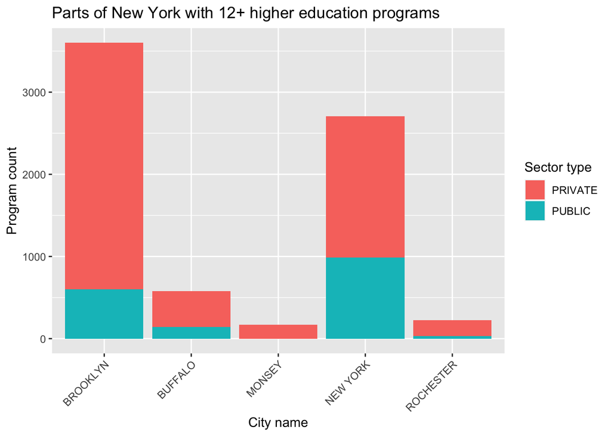

```r
modified_tap_code <- tap_code_2020 %>%
  group_by(city) %>%
  mutate(program_count = n())


modified_tap_code %>%
  filter(program_count > 12) %>%
  ggplot(aes(x = city, y = program_count, fill = sector_type)) +
  geom_bar(stat = "identity") +
  theme(axis.text.x = element_text(angle = 45, hjust = 1)) +
  labs(x = "City name", y = "Program count", title = "Parts of New York with 12+ higher education programs", fill = "Sector type")
```

To clarify, “New York” refers to Manhattan.

Now that we have a pulse on the five cities/towns/boroughs that contain the most higher education programs, let’s explore the relationship between TAP dollars and geography.

## How does the spending of TAP dollars vary across cities/boroughs throughout New York?

Looking at these five towns/cities/boroughs, I calculated the average and median amounts a TAP recipient spends with their grant at each school. The TAP data set considers any student receiving at least a one-term TAP award as a recipient.

```r
tap_city <- tap_code_2020 %>%
  filter(city == "BROOKLYN" | city == "BUFFALO" | city == "MONSEY" | city == "NEW YORK" | city == "ROCHESTER") %>%
  mutate(tap_dollars_by_student = tap_recipient_dollars/tap_recipient_headcount)
```

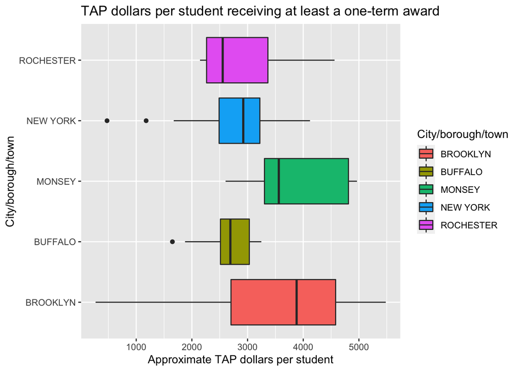

```r
tap_city %>%
  ggplot(aes(x = tap_dollars_by_student, y = city, fill = city)) +
  geom_boxplot() +
  labs(x = "Approximate TAP dollars per student", title = "TAP dollars per student receiving at least a one-term award", y = "City/borough/town", fill = "City/borough/town")
```

This boxplot shows the spread of academic programs in Brooklyn and the varying amounts of TAP dollars the students spend at school, but let’s see how the averages compare.

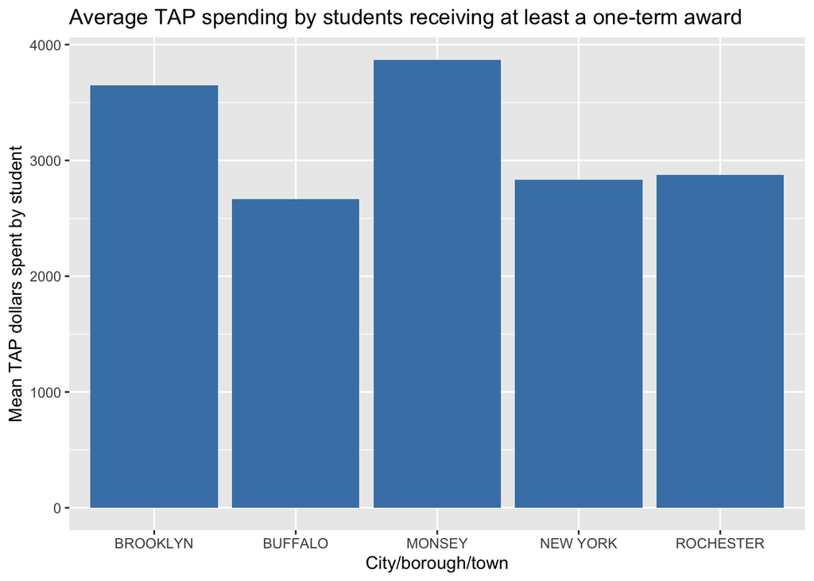

```r
tap_city %>%
  group_by(city) %>%
  summarize(student_mean = mean(tap_dollars_by_student)) %>%
  ggplot(aes(x = city, y = student_mean)) +
  geom_bar(stat = "identity", fill = "steelblue") +
  labs(x = "City/borough/town", y = "Mean TAP dollars spent by student", title = "Average TAP spending by students receiving at least a one-term award")
```

```r
tap_city %>%
  group_by(city) %>%
  summarize("Mean TAP dollars per student" = mean(tap_dollars_by_student, na.rm = TRUE),
            "Median TAP dollars per student" = median(tap_dollars_by_student, na.rm = TRUE))
```

```
# A tibble: 5 × 3
  city      `Mean TAP dollars per student` `Median TAP dollars per student`
  <chr>                              <dbl>                            <dbl>
1 BROOKLYN                           3651.                            3881.
2 BUFFALO                            2668.                            2691.
3 MONSEY                             3869.                            3561.
4 NEW YORK                           2835.                            2923.
5 ROCHESTER                          2873.                            2554.
```

Out of the cities/towns/boroughs with the most higher education institutions, a TAP recipient tends to use the highest amount of TAP award dollars to cover their education in Monsey and Brooklyn. While the median amount is greater for students in Brooklyn, the average amount is greater for students in Monsey, a hamlet with primarily Jewish higher education programs.

## Is there a relationship between the number of TAP recipients and FAFSA applicants in different parts of New York?

Let’s look beyond just TAP. Filling out the FAFSA grants students the opportunity to get financial aid coverage from the federal government. The plot below depicts the relationship between a program’s TAP recipient headcount (including full-time *and* one-term award recipients) and its FAFSA application count in the 2019-2020 application cycle.

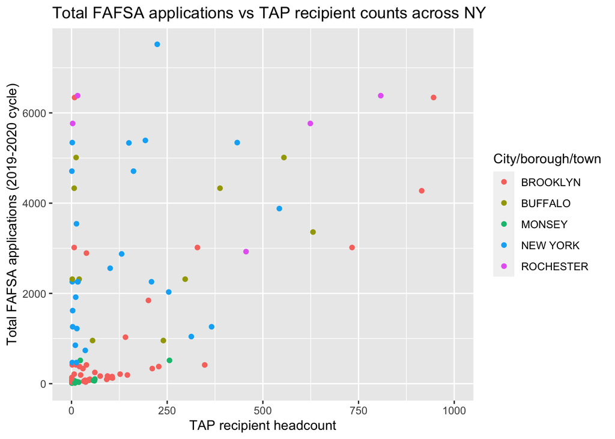

```r
tap_city %>%
  ggplot(aes(x = tap_recipient_headcount, y = total_fafsa_apps_year, color = city)) +
  geom_point() +
  coord_cartesian(xlim = c(0, 1000), ylim = c(0, 7500)) +
  labs(x = "TAP recipient headcount", y = "Total FAFSA applications (2019-2020 cycle)",
       title = "Total FAFSA applications vs TAP recipient counts across NY", color = "City/borough/town")
```

There is a weak positive correlation between total FAFSA applications and TAP recipient headcounts at schools across the five cities/towns/boroughs. This seems like an unsurprising relationship: generally, as more people receive TAP funding, more people apply for financial aid from the government. However, there are some schools with very few TAP recipients (perhaps due to a high out-of-state student population). Since the FAFSA is not specific to New York, those out-of-state students can apply for financial aid that way. This is common with the Manhattan programs (labelled as New York). Other higher education programs — specifically in Brooklyn and Monsey — had relatively lower total FAFSA applications, which could potentially be attributed to smaller program sizes. Monsey’s academic programs are more niche with a heavy religious focus, so they would draw less of a diverse applicant pool.

TAP has [income eligibility limits](https://www.hesc.ny.gov/pay-for-college/apply-for-financial-aid/nys-tap.html), meaning there is an upper bound on how much a family can make to still be eligible for the grant. According to the [Higher Education Services Corporation website](https://www.hesc.ny.gov/pay-for-college/apply-for-financial-aid/nys-tap.html), TAP can only cover up to $5,665 annually. Thus, people who qualify for TAP may still need to look for financial support elsewhere, like through the FAFSA.

## How has the status of TAP changed over the years?

With data tracing back to 2000, TAP’s history is heavily documented. I’ll focus on sector groups, recipient headcounts, and specific academic programs over the years.

TAP has a system of categorizing higher education programs/schools by sector. These sectors include CUNY SR (City University of New York senior colleges), CUNY CC (community colleges), SUNY SO (State University of New York state-operated colleges), SUNY CC (community colleges), independent colleges, business degree-granting programs, business programs that don’t distribute degrees, other programs, and Chapter XXII programs (additional academic programs covered by the New York Code). I wanted to learn more about how the concentration of full-time (opposed to one-term award) TAP recipients across all New York programs has changed over time, while considering these various sector groups. Since some sector groups were not instated until 2011, let’s look from 2011 through 2020.

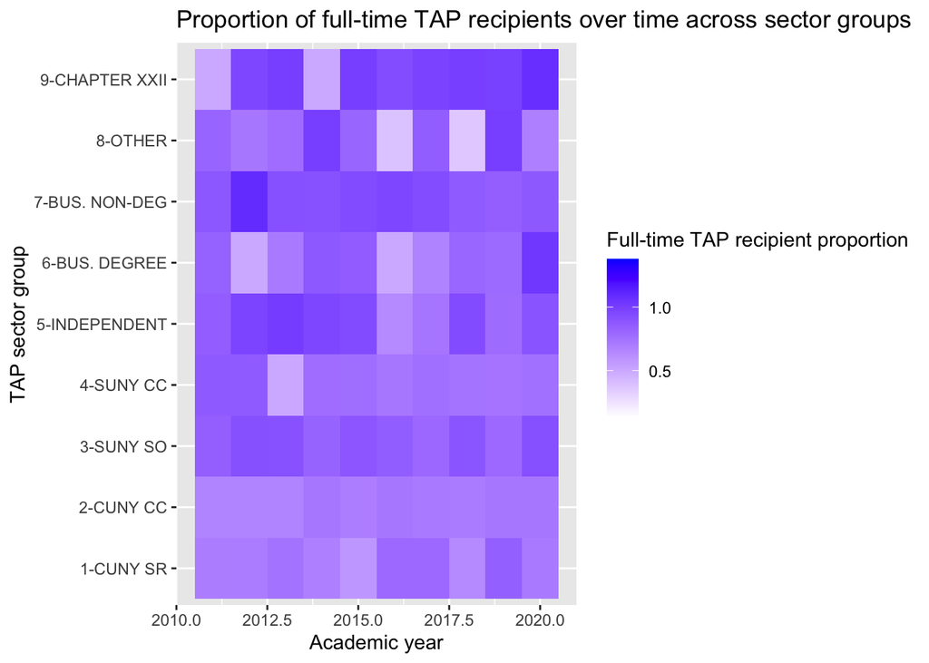

```r
tap_code_general %>%
  mutate(full_time_prop = tap_recipient_ft_es/tap_recipient_headcount) %>%
  filter(academic_year >= 2011) %>%
  ggplot(aes(x = academic_year, y = tap_sector_group)) +
  scale_fill_gradient(low = "white", high = "blue") +
  geom_tile(aes(fill = full_time_prop)) +
  labs(x = "Academic year", y = "TAP sector group", title = "Proportion of full-time TAP recipients over time across sector groups", fill = "Full-time TAP recipient proportion")
```

Over the years, Chapter XXII academic programs have a much stronger population of full-time TAP students, with many recipients getting awards for more than one academic term. The [Chapter XXII sector group allows students to bypass certain eligibility criteria](https://www.hesc.ny.gov/partner-access/financial-aid-professionals/chapter-xxii-tap-schools.html) when applying for TAP grants. All of the higher education programs in Monsey, for example, qualify as Chapter XXII programs. This sector group was specifically designed to allow more students to apply for TAP funding.

Other observations include a relative balance between full-time and not full-time recipients at CUNY community colleges, which has not changed over the years. In 2020, business degree-granting programs, independent programs, Chapter XXII schools, and state-operated SUNY programs had a noticeable boost in full-time TAP recipients compared to the previous year.

Now, let’s home in on some specific programs. [NYU is the largest private university in New York](https://www.collegesimply.com/colleges/rank/private-colleges/largest-enrollment/state/new-york/), so NYU’s TAP recipient headcounts for four-year undergraduate programs can be a good gauge of similar programs.

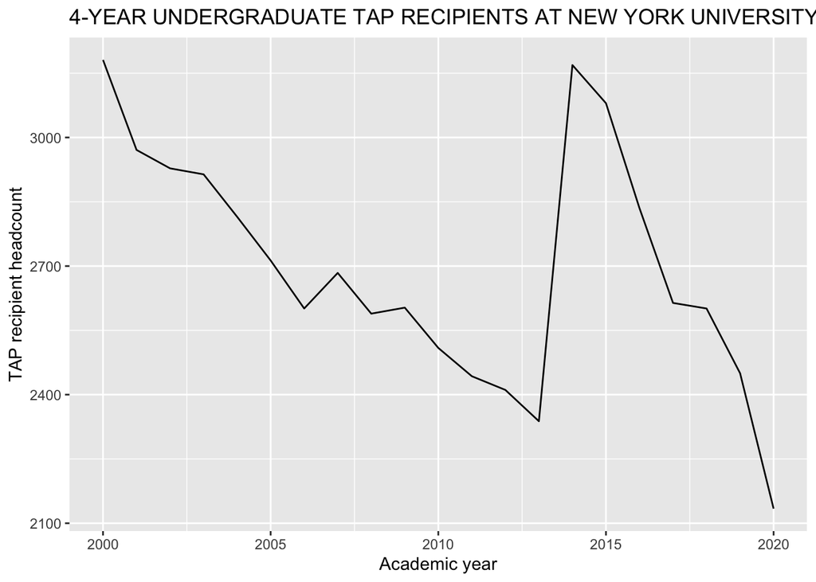

```r
plot_headcount <- function(school) {

  tap_code_general %>%
  filter(school_name == school, tap_level_of_study == "4 yr Undergrad") %>%
    ggplot() +
    geom_line(aes(x = academic_year, y = tap_recipient_headcount)) +
    labs(x = "Academic year", y = "TAP recipient headcount", title = toupper(str_replace("4-year undergraduate TAP recipients at _ ", "_", school)))


}

plot_headcount("NEW YORK UNIVERSITY")
```

I also wanted to look at [the largest public university](https://www.collegesimply.com/colleges/rank/colleges/largest-enrollment/state/new-york/) in the state, which is SUNY at Buffalo.

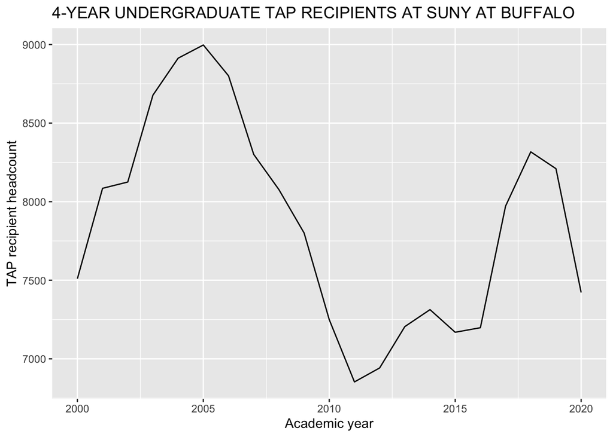

```r
plot_headcount("SUNY AT BUFFALO")
```

To compare, both programs had a spike in TAP recipients in the mid-2010s (starting around 2014 for NYU and 2016 for SUNY at Buffalo). The shared dip in TAP recipients in 2020 may seem surprising because the pandemic led to more students attending school closer to home, prompting more in-state students eligible for TAP funds. However, the government may have put TAP on the back burner while managing the pandemic. As future data rolls out, we should look to see how TAP recovers from this drop.

## Conclusion

Relating TAP, FAFSA, sector, and geographical information gives a better sense of the scope of financial aid offerings over the years.

The rise of the Chapter XXII program afforded more students the opportunity to apply for TAP, especially students in Monsey and institutions specializing in Orthodox Judaism. Out of the five areas with the most higher education programs in New York, Monsey and Brooklyn programs typically receive the most TAP money from students, indicating the amount a student receives from TAP has little to do with geography (Monsey is a small hamlet, whereas Brooklyn is a bustling New York City borough).

Finally, there is a positive — yet weak — correlation between FAFSA applications and TAP recipients, which makes sense considering how TAP recipients do not get full tuition coverage with that program alone.

While FAFSA has a spectrum of financial aid options (ranging from loans to work-study jobs), TAP is purely grant based. In a time with staggering student loan rates, grants are an alternative that do not need to be repaid. The decline of TAP in 2020 is a concerning sign, but, in the past, the program reached across the state to help students afford their education.